# STAT 545 - Homework Assignment 1

Welcome visitors to my repository, my name is Hayden Scheiber! You can reach me at scheiber@chem.ubc.ca

This is assignment 1 for the UBC statistics course STAT 545, in the Fall 2017 term. Click [here](https://github.com/HScheiber/STAT545-hw-Scheiber-Hayden/blob/master/README.md) to return to the main repository.

## About me

I am a new chemistry PhD student at the University of British Columbia. I completed my undergrad in bio-organic chemistry at McGill University, graduating in December 2016. My specialization within chemistry is now physical/computational chemistry. If you would like to view my summer research, you can find it in my Github repository titled [“ALMO-Langevin”](https://github.com/HScheiber/ALMO-Langevin-Manuscript.git). The website for my summer research lab group can be found [here](http://khaliullin.com/).

Over the summer, I did research on *Ab initio* Molecular Dynamics. I worked on developing a new faster method of calculating the electronic structure for the system of interest. My results, posted below, show that we were able to retain fairly good accuracy of bulk properties!

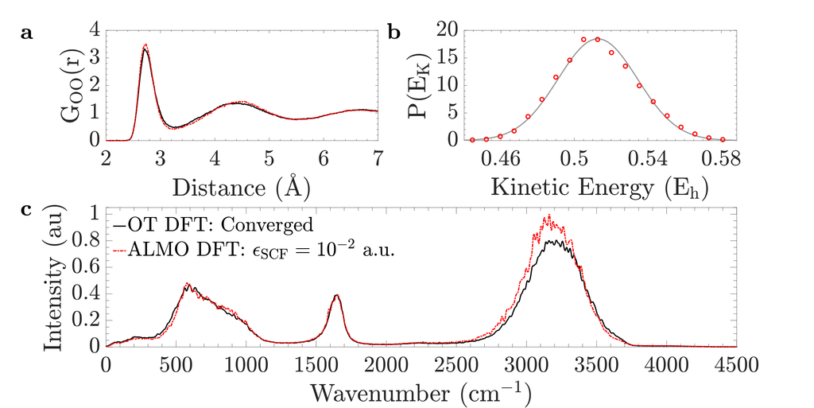

## Gapminder Exploration

Here you can check out my exploration of the Gapminder dataset, which is a massive UN database that compares the populations, gdp per capita, and life expectancy for most countries in 5 year incriments between 1952 and 2007. The R markdown sourcecode can be found [here.](https://github.com/HScheiber/STAT545-hw-Scheiber-Hayden/blob/master/hw01/hw01_gapminder.Rmd)

## Class Resources

- The Github repository for STAT 545 can be found here [here!](https://github.com/STAT545-UBC/STAT545-UBC.github.io.git)
- The main website for STAT 545 created by that repository is found [here.](http://stat545.com/)
- The Slack webpage for STAT 545 is found [here.](https://stat545-2017.slack.com)

# ———————

Thanks for visiting my repository! I’ll leave you with a quote that has stuck with me over the years:

> I mean, they say you die twice. One time when you stop breathing and a second time, a bit later on, when somebody says your name for the last time.

- Banksy

## How I made this file

This is a description of how I made changes to my README.md and hw01_gapminder.Rmd files.

For the README.md file, I initially worked directly on github, making small edits and committing them within the repository. I found this process cumbersome as I couldn’t see whether or not the changes I made would properly be compiled by markdown. Soon after I switched to working in Rstudio and commiting/pushing to git fro there. I found that the workflow was much smoother. I found the [markdown cheat-sheet](https://github.com/adam-p/markdown-here/wiki/Markdown-Cheatsheet) very useful in developing the README file.

For the gapminder exploration file, I worked solely in Rstudio. I used the git functionality within Rstudio to push the files to github.

Making the R markdown document was very straightforward (although I have quite a bit of coding experience in other languages, so my experience probably played a role). The in-class workshop was crutial in getting to know R markdown.